# Prak MPDW 4

Mutiara Andhini

2023-09-12

## White Noise

Pembangkitan data berpola AR, MA, ARMA, dan banyak proses deret waktu lainnya diawali pembangkitan *white noise*. *White noise* merupakan sederet nilai dari peubah bebas stokastik identik. Oleh karena itu, *white noise* memiliki dua karakteristik penting:

1. *White noise* tidak memiliki autokorelasi (**karena saling bebas**)
2. Nilai harapan dan ragam *white noise* sama (**karena berasal dari peubah acak bebas stokastik identik**)

*White noise* dibangkitkan dari suatu peubah acak, umumnya peubah acak normal.

```r
wn <- rnorm(300)
wn
```

```
##   [1]  0.60326768  0.13788160  0.39759875  1.34817518  0.40111404  0.57241935
##   [7] -0.88966679  0.58401257  1.02969234  1.12469134 -1.21324105 -0.20791777
##  [13] -0.25759651 -0.45039820 -0.74492077 -0.28818558 -0.20272390  0.72629745
##  [19] -0.36024538 -0.39104714  0.88263130 -0.22144366 -1.18058357 -1.00185436
##  [25]  0.34012593 -1.95462128 -0.27747506  0.06451669 -0.35435871 -0.31614851
##  [31] -0.50316735 -1.02452290 -0.07653333  0.14656664  2.16772584  1.07352503
##  [37] -0.53751040  1.74243662  0.07421343 -0.11166168  0.21121552  1.09867688
##  [43] -0.96732867  0.35366614 -1.29465664 -2.08558081 -0.97354535  0.38490650
##  [49]  1.87858375  0.17494171 -0.22380232  0.70989497  0.65654284 -0.84180528
##  [55] -0.36532251  0.24476775 -0.22931270  0.77229481  0.36476832 -0.03717381
##  [61] -1.01410086 -1.63621839 -0.57865192 -1.25819415 -0.95191582  0.99807928
##  [67] -0.50979082  0.69191378  0.01115046 -0.06586940 -0.70905579 -0.77999345
##  [73] -2.00113841  0.89472006  1.28079345  3.00528976 -3.20279273  0.91509662
##  [79]  0.52457380  1.77914774 -2.18195846  1.42010246  2.06797820 -1.11459166
##  [85]  0.67628366  0.54953811 -0.22137289 -0.65752236  1.14094902 -0.61800569
```

[output cut: 35 more lines]

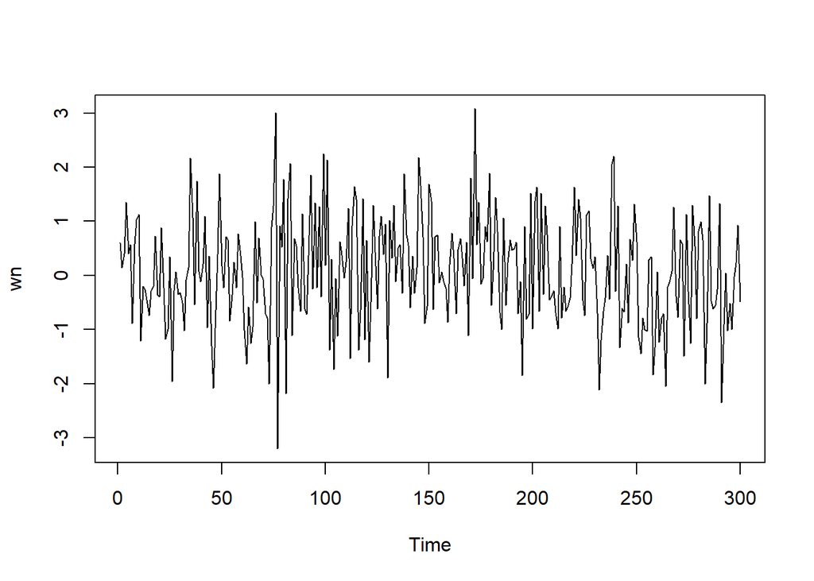

```r
ts.plot(wn)
```

Dapat terlihat bahwa *white noise* tidak memiliki autokorelasi dari ACF. Perhatikan bahwa lag ke-0 adalah korelasi observasi ke-t dengan dirinya sendiri. Nilai korelasi tersebut pasti 1. Sebagai alternatif, lag pertama di plot ACF dapat ditetapkan sebagai 1 (alih-alih 0) dengan menambahkan argumen `xlim(1, lag akhir)`. Plot tersebut dapat disandingkan bersamaan dengan membuat matriks $1 \times 2$ dengan `par(mfrow = c(1,2))`.

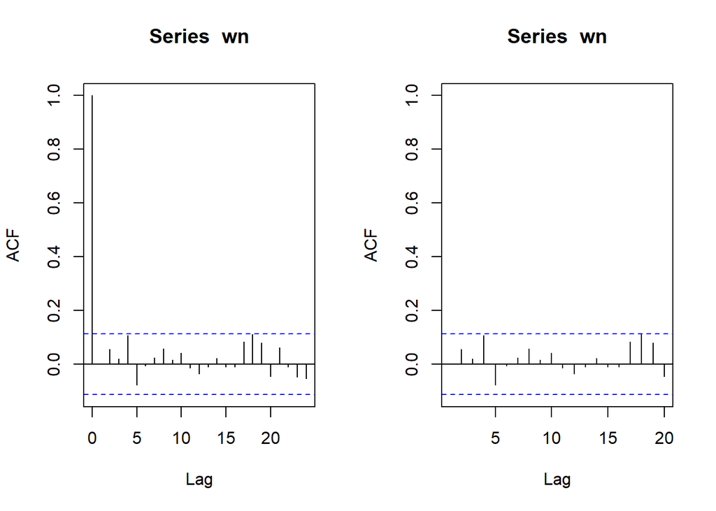

```r
par(mfrow = c(1, 2))
acf(wn)
acf(wn, xlim = c(1, 20))
```

## Proses MA

Proses MA dapat dituliskan sebagai berikut:

$$y_{t} = c + e_t + \theta_{1}e_{t-1} + \theta_{2}e_{t-2} + \dots +
\theta_{q}e_{t-q} = c+{e_t+\sum_{i=1}^p \theta_ie_{t-i}}$$
Terlihat bahwa $e_t$, atau *white noise*, berperan penting dalam pembangkitan proses MA.

## Pembangkitan Proses MA(2)

```r
set.seed(1010)
ma2 <- wn[1]
ma2
```

```
## [1] 0.6032677
```

Nilai-nilai selanjutnya dapat dicari melalui *loop*. Bentuk loop dapat dilihat dari rumus MA(2) yang hendak dibangkitkan:

```r
for(i in 3:300){
   ma2[i] <- wn[i] - wn[i-1] - 0.6 * wn[i - 2]
}
ma2
```

```
##   [1]  0.6032676753            NA -0.1022434522  0.8678474693 -1.1856203941
##   [6] -0.6375997901 -1.7027545651  1.1302277508  0.9794798425 -0.2554085416
##  [11] -2.9557477945  0.3305084805  0.6782658839 -0.0680510239 -0.1399646588
##  [16]  0.7269741088  0.5324141406  1.1019326923 -0.9649084902 -0.4665802316
##  [21]  1.4898256708 -0.8694466806 -1.4887186975  0.3115954074  2.0503304385
##  [26] -1.6936345984  1.4730706631  1.5147645196 -0.2523903573 -0.0004998124
##  [31]  0.0255963817 -0.3316664454  1.2498899821  0.8378137100  2.0670791912
##  [36] -1.1821407980 -2.9116709295  1.6358320062 -1.3457169590 -1.2313370784
##  [41]  0.2783491373  0.9544583717 -2.1927348600  0.6617886806 -1.0679255824
##  [46] -1.0031238539  1.8888294388  2.6098003401  2.0778044675 -1.9345859428
##  [51] -1.5258942876  0.8287322647  0.0809292602 -1.9242850966  0.0825570641
##  [56]  1.1151734272 -0.2548869400  0.8547468656 -0.2699388794 -0.8653190178
##  [61] -1.1957880365 -0.5998132394  1.6660269838  0.3021888045  0.6534694853
##  [66]  2.7049115963 -0.9367206110  0.6028570299 -0.3748888313 -0.4921681260
##  [71] -0.6498766730 -0.0314160131 -0.7957114840  3.3638545363  1.5867564339
```

[output cut: 45 more lines]

```r
ma2 <- arima.sim(list(order=c(0,0,2), ma= c(0.4, 0.6)), n=300)
ma2
```

```
## Time Series:
## Start = 1
## End = 300
## Frequency = 1
##   [1]  1.071705175  0.422106613  0.690736960  1.501222304  2.311474041
##   [6] -0.766756080 -0.375272150 -2.198788160 -0.770197848 -1.235168383
##  [11] -1.884954880 -1.148267311 -0.165788735 -0.543028834 -0.698251506
##  [16] -0.595470096 -1.361763778 -1.223980621 -0.872896857  0.169333233
##  [21] -0.629372146  0.504724047 -1.080874546  0.741720747 -0.434947966
##  [26] -0.736240440 -0.898001000 -2.583414475 -1.946601852  0.405487512
##  [31] -0.001458042  1.425295218 -0.992023400  0.135076591 -0.756077274
##  [36] -0.286595860 -0.890964944 -1.451956836 -1.119449938 -0.332941093
##  [41] -0.149323883  0.900367374 -0.471636090  0.291421594 -0.027813907
##  [46] -0.360449808  0.298325813  1.103341959  2.564457298  0.752839686
##  [51] -0.349149879 -1.291486161 -0.809197685 -0.392505751  0.872787277
```

[output cut: 49 more lines]

## Karakteristik MA(2)

### Plot Time Series

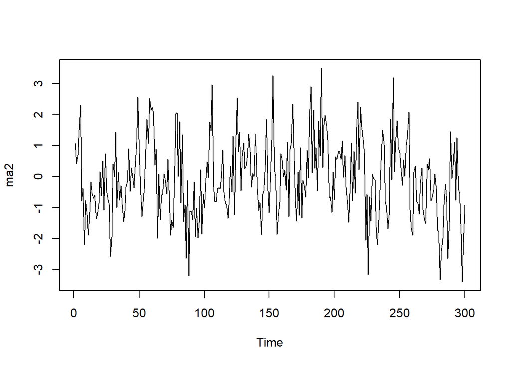

```r
ts.plot(ma2)
```

### Plot ACF

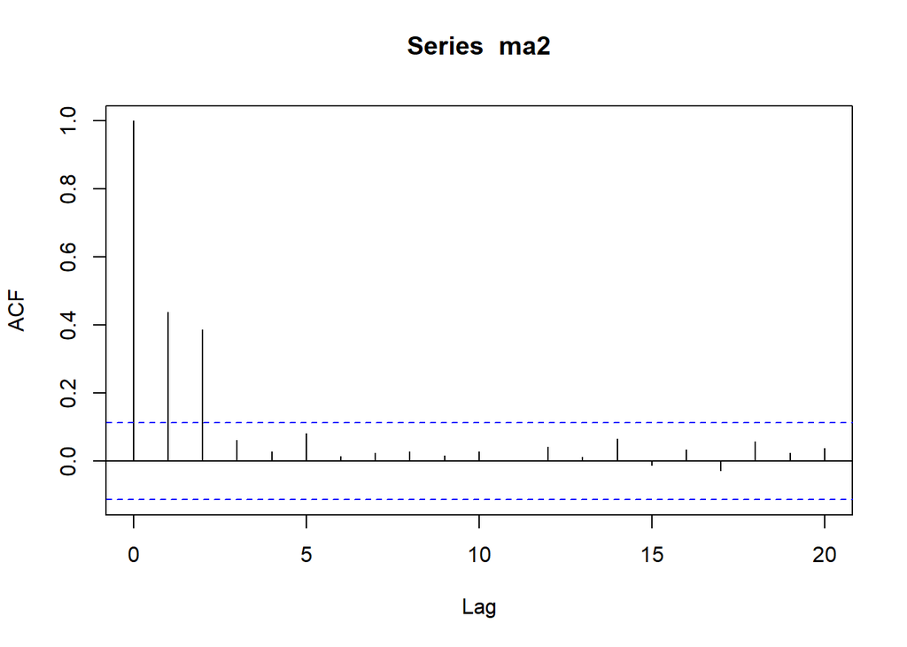

```r
acf(ma2,lag.max = 20)
```

### Plot PACF

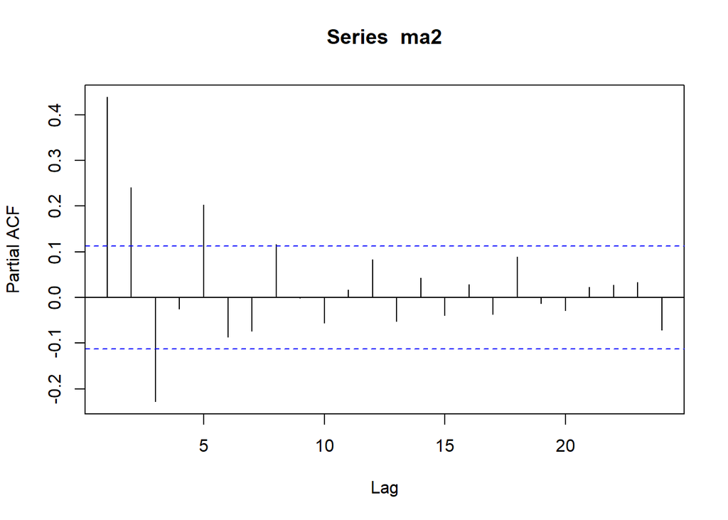

```r
pacf(ma2)
```

Berdasarkan plot PACF tersebut, terlihat bahwa plot PACF cenderung *tails off* dan membentuk gelombang sinus

### Plot EACF

```r
TSA::eacf(ma2)
```

```
## AR/MA
##   0 1 2 3 4 5 6 7 8 9 10 11 12 13
## 0 x x o o o o o o o o o  o  o  o
## 1 x x x o o o o o o o o  o  o  o
## 2 x x o x o o o o o o o  o  o  o
## 3 o x o x o o o o o o o  o  o  o
## 4 x x x x o o o o o o o  o  o  o
## 5 x x x x o o o o o o o  o  o  o
## 6 x x x o o o o o o o o  o  o  o
## 7 x x x o o o o o o o o  o  o  o
```

### Scatterplot Antar Lag

#### Korelasi antara $Y_t$ dengan $Y_{t-1}$

```r
#Yt
yt_ma2 <- ma2[-1]
yt_ma2
```

```
##   [1]  0.422106613  0.690736960  1.501222304  2.311474041 -0.766756080
##   [6] -0.375272150 -2.198788160 -0.770197848 -1.235168383 -1.884954880
##  [11] -1.148267311 -0.165788735 -0.543028834 -0.698251506 -0.595470096
##  [16] -1.361763778 -1.223980621 -0.872896857  0.169333233 -0.629372146
##  [21]  0.504724047 -1.080874546  0.741720747 -0.434947966 -0.736240440
##  [26] -0.898001000 -2.583414475 -1.946601852  0.405487512 -0.001458042
##  [31]  1.425295218 -0.992023400  0.135076591 -0.756077274 -0.286595860
##  [36] -0.890964944 -1.451956836 -1.119449938 -0.332941093 -0.149323883
##  [41]  0.900367374 -0.471636090  0.291421594 -0.027813907 -0.360449808
##  [46]  0.298325813  1.103341959  2.564457298  0.752839686 -0.349149879
##  [51] -1.291486161 -0.809197685 -0.392505751  0.872787277  1.853672380
##  [56]  1.074961292  2.524086251  2.143785091  2.242967913  2.051877771
##  [61]  0.367790380  0.884919174 -1.987698959  0.081619557 -1.399009877
##  [66] -0.602541199 -0.573444638  0.085263990 -0.098161217 -0.549525949
##  [71]  0.557429691 -0.441211933 -1.884837560 -1.408256548 -1.643425317
```

[output cut: 45 more lines]

```r
#Yt-1
yt_1_ma2 <- ma2[-300]
yt_1_ma2
```

```
##   [1]  1.071705175  0.422106613  0.690736960  1.501222304  2.311474041
##   [6] -0.766756080 -0.375272150 -2.198788160 -0.770197848 -1.235168383
##  [11] -1.884954880 -1.148267311 -0.165788735 -0.543028834 -0.698251506
##  [16] -0.595470096 -1.361763778 -1.223980621 -0.872896857  0.169333233
##  [21] -0.629372146  0.504724047 -1.080874546  0.741720747 -0.434947966
##  [26] -0.736240440 -0.898001000 -2.583414475 -1.946601852  0.405487512
##  [31] -0.001458042  1.425295218 -0.992023400  0.135076591 -0.756077274
##  [36] -0.286595860 -0.890964944 -1.451956836 -1.119449938 -0.332941093
##  [41] -0.149323883  0.900367374 -0.471636090  0.291421594 -0.027813907
##  [46] -0.360449808  0.298325813  1.103341959  2.564457298  0.752839686
##  [51] -0.349149879 -1.291486161 -0.809197685 -0.392505751  0.872787277
##  [56]  1.853672380  1.074961292  2.524086251  2.143785091  2.242967913
##  [61]  2.051877771  0.367790380  0.884919174 -1.987698959  0.081619557
##  [66] -1.399009877 -0.602541199 -0.573444638  0.085263990 -0.098161217
##  [71] -0.549525949  0.557429691 -0.441211933 -1.884837560 -1.408256548
```

[output cut: 45 more lines]

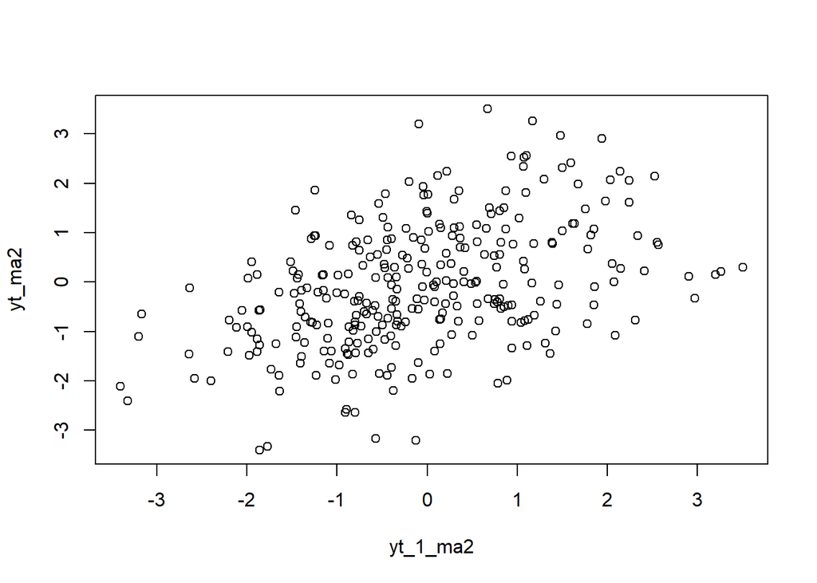

```r
plot(y=yt_ma2,x=yt_1_ma2)
```

Berdasarkan scatterplot tersebut, terlihat bahwa terdapat hubungan positif antara $Y_t$ dengan $Y_{t-1}$. Hal ini sesuai dengan teori yang ada

```r
cor(yt_ma2,yt_1_ma2)
```

```
## [1] 0.4390397
```

Korelasi antara $Y_t$ dengan $Y_{t-1}$ dari hasil simulasi mendekati perhitungan teoritis yaitu

$$\rho_1=\frac{-\theta_1+\theta_1\theta_2
}{1+\theta_1^2+\theta_2^2}=\frac{0.4+(-0.4)(-0.6)}{1+(-0.4)^2+(-0.6)^2}=0.4$$

#### Korelasi antara $Y_t$ dengan $Y_{t-2}$

```r
#Yt
yt_ma2 <- ma2[-c(1,2)]
yt_ma2
```

```
##   [1]  0.690736960  1.501222304  2.311474041 -0.766756080 -0.375272150
##   [6] -2.198788160 -0.770197848 -1.235168383 -1.884954880 -1.148267311
##  [11] -0.165788735 -0.543028834 -0.698251506 -0.595470096 -1.361763778
##  [16] -1.223980621 -0.872896857  0.169333233 -0.629372146  0.504724047
##  [21] -1.080874546  0.741720747 -0.434947966 -0.736240440 -0.898001000
##  [26] -2.583414475 -1.946601852  0.405487512 -0.001458042  1.425295218
##  [31] -0.992023400  0.135076591 -0.756077274 -0.286595860 -0.890964944
##  [36] -1.451956836 -1.119449938 -0.332941093 -0.149323883  0.900367374
##  [41] -0.471636090  0.291421594 -0.027813907 -0.360449808  0.298325813
##  [46]  1.103341959  2.564457298  0.752839686 -0.349149879 -1.291486161
##  [51] -0.809197685 -0.392505751  0.872787277  1.853672380  1.074961292
##  [56]  2.524086251  2.143785091  2.242967913  2.051877771  0.367790380
##  [61]  0.884919174 -1.987698959  0.081619557 -1.399009877 -0.602541199
##  [66] -0.573444638  0.085263990 -0.098161217 -0.549525949  0.557429691
##  [71] -0.441211933 -1.884837560 -1.408256548 -1.643425317 -0.199802210
```

[output cut: 45 more lines]

```r
#Yt-2
yt_2_ma2 <- ma2[-c(299,300)]
yt_2_ma2
```

```
##   [1]  1.071705175  0.422106613  0.690736960  1.501222304  2.311474041
##   [6] -0.766756080 -0.375272150 -2.198788160 -0.770197848 -1.235168383
##  [11] -1.884954880 -1.148267311 -0.165788735 -0.543028834 -0.698251506
##  [16] -0.595470096 -1.361763778 -1.223980621 -0.872896857  0.169333233
##  [21] -0.629372146  0.504724047 -1.080874546  0.741720747 -0.434947966
##  [26] -0.736240440 -0.898001000 -2.583414475 -1.946601852  0.405487512
##  [31] -0.001458042  1.425295218 -0.992023400  0.135076591 -0.756077274
##  [36] -0.286595860 -0.890964944 -1.451956836 -1.119449938 -0.332941093
##  [41] -0.149323883  0.900367374 -0.471636090  0.291421594 -0.027813907
##  [46] -0.360449808  0.298325813  1.103341959  2.564457298  0.752839686
##  [51] -0.349149879 -1.291486161 -0.809197685 -0.392505751  0.872787277
##  [56]  1.853672380  1.074961292  2.524086251  2.143785091  2.242967913
##  [61]  2.051877771  0.367790380  0.884919174 -1.987698959  0.081619557
##  [66] -1.399009877 -0.602541199 -0.573444638  0.085263990 -0.098161217
##  [71] -0.549525949  0.557429691 -0.441211933 -1.884837560 -1.408256548
```

[output cut: 45 more lines]

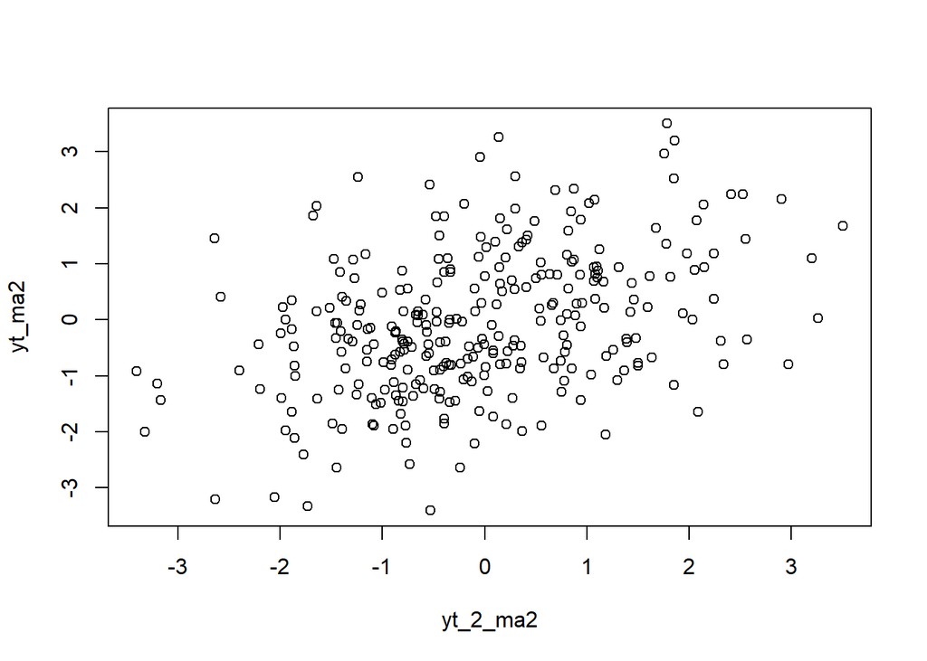

```r
plot(y=yt_ma2,x=yt_2_ma2)
```

```r
cor(yt_ma2,yt_2_ma2)
```

```
## [1] 0.3893185
```

#### Korelasi antara $Y_t$ dengan $Y_{t-3}$

```r
#Yt
yt_ma2 <- ma2[-c(1,2,3)]
yt_ma2
```

```
##   [1]  1.501222304  2.311474041 -0.766756080 -0.375272150 -2.198788160
##   [6] -0.770197848 -1.235168383 -1.884954880 -1.148267311 -0.165788735
##  [11] -0.543028834 -0.698251506 -0.595470096 -1.361763778 -1.223980621
##  [16] -0.872896857  0.169333233 -0.629372146  0.504724047 -1.080874546
##  [21]  0.741720747 -0.434947966 -0.736240440 -0.898001000 -2.583414475
##  [26] -1.946601852  0.405487512 -0.001458042  1.425295218 -0.992023400
##  [31]  0.135076591 -0.756077274 -0.286595860 -0.890964944 -1.451956836
##  [36] -1.119449938 -0.332941093 -0.149323883  0.900367374 -0.471636090
##  [41]  0.291421594 -0.027813907 -0.360449808  0.298325813  1.103341959
##  [46]  2.564457298  0.752839686 -0.349149879 -1.291486161 -0.809197685
##  [51] -0.392505751  0.872787277  1.853672380  1.074961292  2.524086251
##  [56]  2.143785091  2.242967913  2.051877771  0.367790380  0.884919174
##  [61] -1.987698959  0.081619557 -1.399009877 -0.602541199 -0.573444638
##  [66]  0.085263990 -0.098161217 -0.549525949  0.557429691 -0.441211933
##  [71] -1.884837560 -1.408256548 -1.643425317 -0.199802210  2.034818368
```

[output cut: 45 more lines]

```r
#Yt-2
yt_3_ma2 <- ma2[-c(298,299,300)]
yt_3_ma2
```

```
##   [1]  1.071705175  0.422106613  0.690736960  1.501222304  2.311474041
##   [6] -0.766756080 -0.375272150 -2.198788160 -0.770197848 -1.235168383
##  [11] -1.884954880 -1.148267311 -0.165788735 -0.543028834 -0.698251506
##  [16] -0.595470096 -1.361763778 -1.223980621 -0.872896857  0.169333233
##  [21] -0.629372146  0.504724047 -1.080874546  0.741720747 -0.434947966
##  [26] -0.736240440 -0.898001000 -2.583414475 -1.946601852  0.405487512
##  [31] -0.001458042  1.425295218 -0.992023400  0.135076591 -0.756077274
##  [36] -0.286595860 -0.890964944 -1.451956836 -1.119449938 -0.332941093
##  [41] -0.149323883  0.900367374 -0.471636090  0.291421594 -0.027813907
##  [46] -0.360449808  0.298325813  1.103341959  2.564457298  0.752839686
##  [51] -0.349149879 -1.291486161 -0.809197685 -0.392505751  0.872787277
##  [56]  1.853672380  1.074961292  2.524086251  2.143785091  2.242967913
##  [61]  2.051877771  0.367790380  0.884919174 -1.987698959  0.081619557
##  [66] -1.399009877 -0.602541199 -0.573444638  0.085263990 -0.098161217
##  [71] -0.549525949  0.557429691 -0.441211933 -1.884837560 -1.408256548
```

[output cut: 45 more lines]

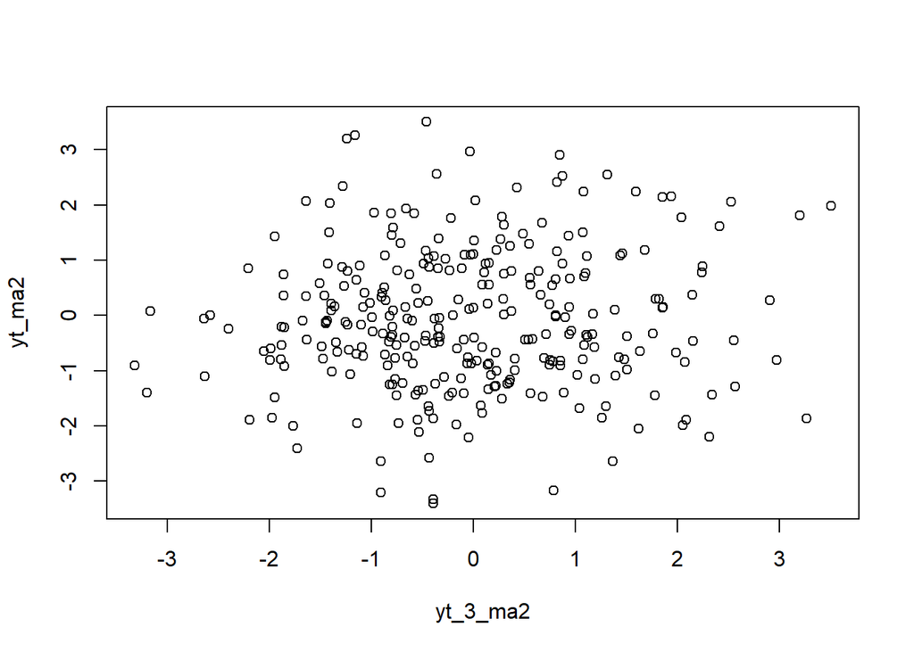

```r
plot(y=yt_ma2,x=yt_3_ma2)
```

Berdasarkan scatterplot tersebut, terlihat bahwa cenderung tidak terdapat hubungan antara $Y_t$ dengan $Y_{t-3}$.

```r
cor(yt_ma2,yt_3_ma2)
```

```
## [1] 0.06201257
```

## Proses AR2

Proses AR dapat dituliskan sebagai berikut:

$$y_{t} = c + e_t + \phi_{1}Y_{t-1} +
\phi_{2}Y_{t-2} + \dots + \phi_{q}Y_{t-q} = c+{e_t+\sum_{i=1}^p
\phi_iY_{t-i}}$$
Terlihat bahwa $Y_t$ berperan penting dalam pembangkitan proses AR.

## Pembangkitan Proses AR2

Akan dicoba membangkitkan proses AR paling sederhana, yaitu AR(2) dengan $\phi = 0.5$ dan $\phi = 0.2$ sebanyak 300 observasi dan $c=0$.

```r
set.seed(1010)
```

$$Y_t = e_t+0.5Y_{t-1}+0.2Y_{t-2}$$

```r
n<-length(wn)
n
```

```
## [1] 300
```

```r
ar <- c(1:n)
for (i in 3:n) {ar[i]<-wn[i]+0.5*ar[i-1]+0.2*ar[i-2]}
ar
```

```
##   [1]  1.00000000  2.00000000  1.59759875  2.54697455  1.99412106  2.07887479
##   [7]  0.54859482  1.27408494  1.77645377  2.26773521  0.27591731  0.38358793
##  [13] -0.01061909 -0.37899016 -0.93653966 -0.83225344 -0.80615855  0.15676749
##  [19] -0.44309334 -0.58124031  0.50339248 -0.08599548 -1.12290282 -1.58050487
##  [25] -0.67470707 -2.60807579 -1.71645437 -1.31532566 -1.35531241 -1.25686984
##  [31] -1.40266475 -1.97722924 -1.34568090 -0.92171965  1.43772983  1.60804601
##  [37]  0.55405857  2.34107511  1.35556270  1.03433470  0.99949540  1.80529152
##  [43]  0.13521618  0.78233253 -0.87644714 -2.36733787 -2.33250372 -1.25481293
##  [49]  0.78467654  0.31631740  0.09129169  0.81880429  1.08420332 -0.13594276
##  [55] -0.21645323  0.10935258 -0.21792706  0.68520180  0.66378381  0.43175845
##  [61] -0.66546488 -1.88259914 -1.65304447 -2.46123621 -2.51314282 -0.75073937
##  [67] -1.38778907 -0.15212862 -0.34247167 -0.26753096 -0.91131561 -1.28915744
##  [73] -2.82798025 -0.77710155  0.32664663  3.01319277 -1.63086702  0.70230166
##  [79]  0.54955123  2.19438368 -0.97485637  1.37155102  2.55878243  0.43910976
##  [85]  1.40759502  1.34115757  0.73072490 -0.02392839  1.27512981  0.01477353
```

[output cut: 35 more lines]

Selain menggunakan cara di atas, pembangkitan proses AR dapat dilakukan dengan fungsi `arima.sim()` sebagai berikut.

```r
ar2 <- arima.sim(list(order=c(2,0,0), ar=c(0.5,0.2)), n=300)
ar2
```

```
## Time Series:
## Start = 1
## End = 300
## Frequency = 1
##   [1]  0.133295622 -0.471960465 -1.261288985 -1.010957436 -2.595601924
##   [6] -2.539895627  0.135099830 -0.587612557  0.062881427 -1.121662286
##  [11] -0.196746715 -0.598038053 -0.725736220 -1.053294182 -1.663003076
##  [16] -1.422635739 -0.629944187 -0.686127624  0.217581499 -0.722747495
##  [21] -0.160691255  0.101012122 -0.566744612  0.073656551  1.243158192
##  [26]  2.470800309  0.711268215 -0.290944221 -0.374751126 -0.221705995
##  [31] -0.364932743  0.703316468  1.867772162  0.955796053  2.469579753
##  [36]  2.993735253  2.635760648  2.769842617  1.551591479  1.846947075
##  [41] -0.744491075  0.559766910 -0.306104105 -0.806377951 -0.469489115
##  [46]  0.150443138 -0.332375194 -0.888023314  0.535932097 -0.318263458
##  [51] -2.401184208 -1.487630879 -1.368579826 -0.989775631  1.356114931
```

[output cut: 49 more lines]

## Karakteristik AR(2)

### Plot Time Series

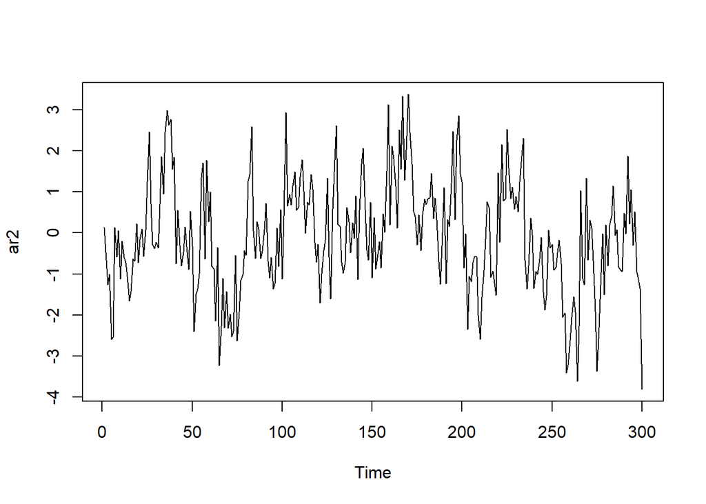

```r
ts.plot(ar2)
```

Berdasarkan plot time series tersebut terlihat bahwa data cenderung stasioner pada rataan

### Plot ACF

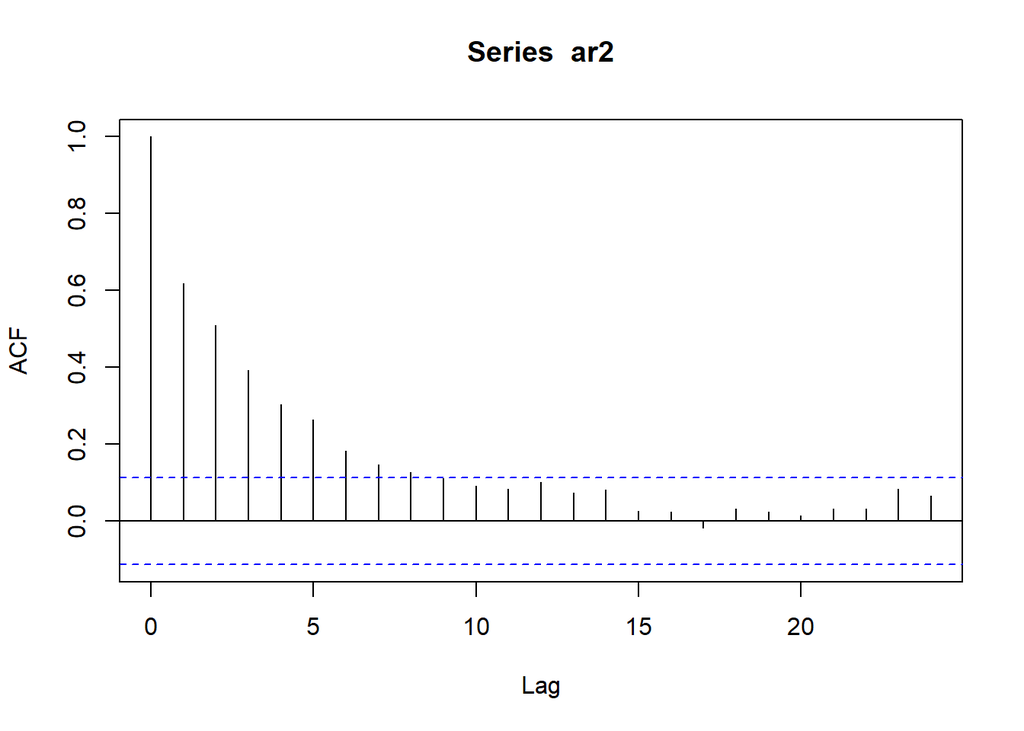

```r
acf(ar2)
```

### Plot PACF

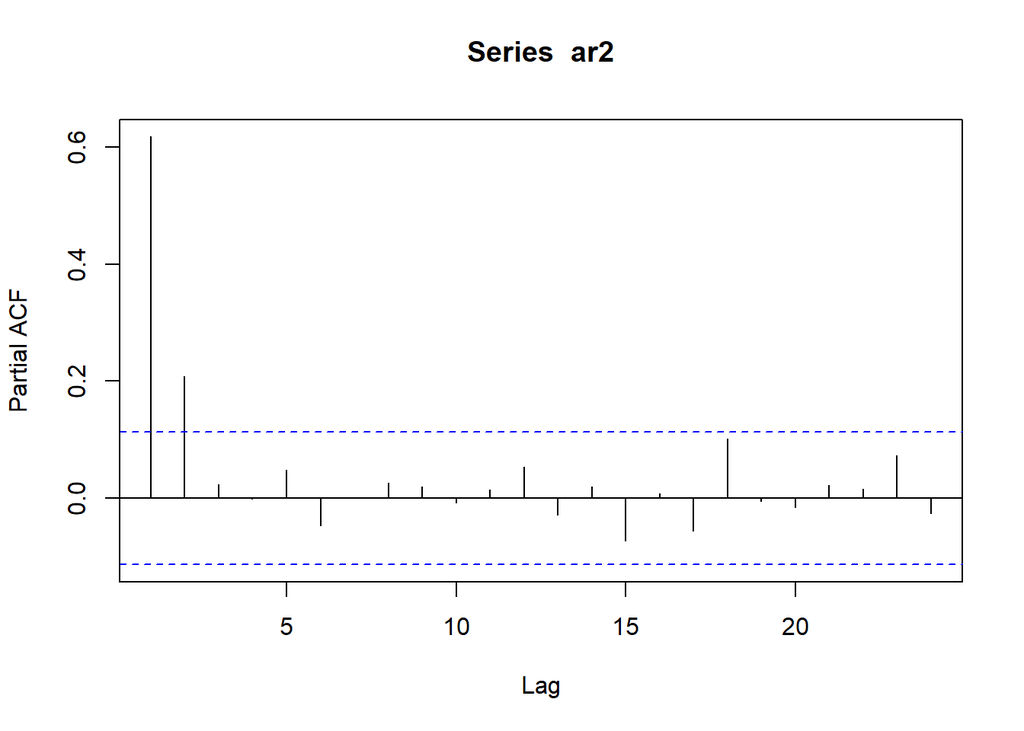

```r
pacf(ar2)
```

### Plot EACF

```r
TSA::eacf(ar2)
```

```
## AR/MA
##   0 1 2 3 4 5 6 7 8 9 10 11 12 13
## 0 x x x x x x x x o o o  o  o  o
## 1 x o o o o o o o o o o  o  o  o
## 2 o o o o o o o o o o o  o  o  o
## 3 o o o o o o o o o o o  o  o  o
## 4 o x o o o o o o o o o  o  o  o
## 5 x x x o o o o o o o o  o  o  o
## 6 o x x o o o o o o o o  o  o  o
## 7 x x x o o o o o o o o  o  o  o
```

### Scatterplot Antar Lag

#### Korelasi antara $Y_t$ dengan $Y_{t-1}$

```r
#Yt
yt_ar2 <- ar[-1]
yt_ar2
```

```
##   [1]  2.00000000  1.59759875  2.54697455  1.99412106  2.07887479  0.54859482
##   [7]  1.27408494  1.77645377  2.26773521  0.27591731  0.38358793 -0.01061909
##  [13] -0.37899016 -0.93653966 -0.83225344 -0.80615855  0.15676749 -0.44309334
##  [19] -0.58124031  0.50339248 -0.08599548 -1.12290282 -1.58050487 -0.67470707
##  [25] -2.60807579 -1.71645437 -1.31532566 -1.35531241 -1.25686984 -1.40266475
##  [31] -1.97722924 -1.34568090 -0.92171965  1.43772983  1.60804601  0.55405857
##  [37]  2.34107511  1.35556270  1.03433470  0.99949540  1.80529152  0.13521618
##  [43]  0.78233253 -0.87644714 -2.36733787 -2.33250372 -1.25481293  0.78467654
##  [49]  0.31631740  0.09129169  0.81880429  1.08420332 -0.13594276 -0.21645323
##  [55]  0.10935258 -0.21792706  0.68520180  0.66378381  0.43175845 -0.66546488
##  [61] -1.88259914 -1.65304447 -2.46123621 -2.51314282 -0.75073937 -1.38778907
##  [67] -0.15212862 -0.34247167 -0.26753096 -0.91131561 -1.28915744 -2.82798025
##  [73] -0.77710155  0.32664663  3.01319277 -1.63086702  0.70230166  0.54955123
##  [79]  2.19438368 -0.97485637  1.37155102  2.55878243  0.43910976  1.40759502
##  [85]  1.34115757  0.73072490 -0.02392839  1.27512981  0.01477353 -0.45086011
```

[output cut: 35 more lines]

```r
#Yt-1
yt_1_ar2 <- ar[-300]
yt_1_ar2
```

```
##   [1]  1.00000000  2.00000000  1.59759875  2.54697455  1.99412106  2.07887479
##   [7]  0.54859482  1.27408494  1.77645377  2.26773521  0.27591731  0.38358793
##  [13] -0.01061909 -0.37899016 -0.93653966 -0.83225344 -0.80615855  0.15676749
##  [19] -0.44309334 -0.58124031  0.50339248 -0.08599548 -1.12290282 -1.58050487
##  [25] -0.67470707 -2.60807579 -1.71645437 -1.31532566 -1.35531241 -1.25686984
##  [31] -1.40266475 -1.97722924 -1.34568090 -0.92171965  1.43772983  1.60804601
##  [37]  0.55405857  2.34107511  1.35556270  1.03433470  0.99949540  1.80529152
##  [43]  0.13521618  0.78233253 -0.87644714 -2.36733787 -2.33250372 -1.25481293
##  [49]  0.78467654  0.31631740  0.09129169  0.81880429  1.08420332 -0.13594276
##  [55] -0.21645323  0.10935258 -0.21792706  0.68520180  0.66378381  0.43175845
##  [61] -0.66546488 -1.88259914 -1.65304447 -2.46123621 -2.51314282 -0.75073937
##  [67] -1.38778907 -0.15212862 -0.34247167 -0.26753096 -0.91131561 -1.28915744
##  [73] -2.82798025 -0.77710155  0.32664663  3.01319277 -1.63086702  0.70230166
##  [79]  0.54955123  2.19438368 -0.97485637  1.37155102  2.55878243  0.43910976
##  [85]  1.40759502  1.34115757  0.73072490 -0.02392839  1.27512981  0.01477353
```

[output cut: 35 more lines]

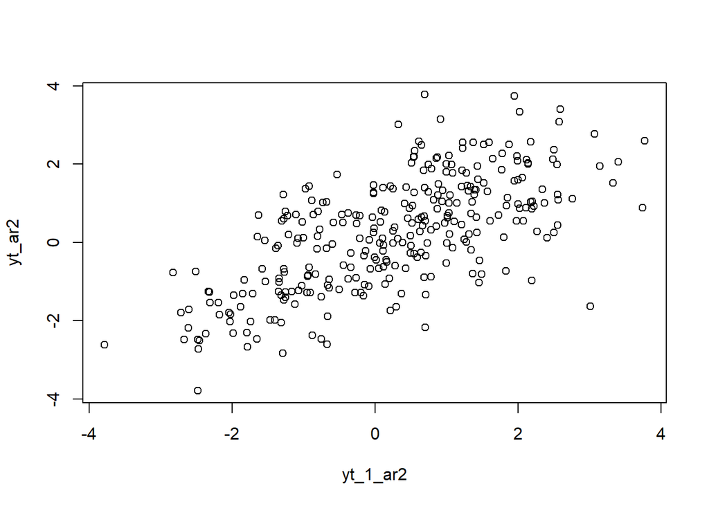

```r
plot(y=yt_ar2,x=yt_1_ar2)
```

Berdasarkan scatterplot tersebut, terlihat bahwa terdapat hubungan positif antara $Y_t$ dengan $Y_{t-1}$. Hal ini sesuai dengan teori yang ada

```r
cor(yt_ar2,yt_1_ar2)
```

```
## [1] 0.6726797
```

#### Korelasi antara $Y_t$ dengan $Y_{t-2}$

```r
#Yt
yt_ar2 <- ar2[-c(1,2)]
yt_ar2
```

```
##   [1] -1.261288985 -1.010957436 -2.595601924 -2.539895627  0.135099830
##   [6] -0.587612557  0.062881427 -1.121662286 -0.196746715 -0.598038053
##  [11] -0.725736220 -1.053294182 -1.663003076 -1.422635739 -0.629944187
##  [16] -0.686127624  0.217581499 -0.722747495 -0.160691255  0.101012122
##  [21] -0.566744612  0.073656551  1.243158192  2.470800309  0.711268215
##  [26] -0.290944221 -0.374751126 -0.221705995 -0.364932743  0.703316468
##  [31]  1.867772162  0.955796053  2.469579753  2.993735253  2.635760648
##  [36]  2.769842617  1.551591479  1.846947075 -0.744491075  0.559766910
##  [41] -0.306104105 -0.806377951 -0.469489115  0.150443138 -0.332375194
##  [46] -0.888023314  0.535932097 -0.318263458 -2.401184208 -1.487630879
##  [51] -1.368579826 -0.989775631  1.356114931  1.709392163 -0.633670165
##  [56]  1.770677990  0.274219021  1.000219974 -0.808515059 -0.871916643
##  [61] -2.151063102 -0.350407053 -3.234663999 -2.279539723 -1.114053857
##  [66] -2.319244900 -1.430136190 -2.322809507 -1.975066728 -2.531479937
##  [71] -2.399113628 -0.538788396 -2.628538819 -1.931605552 -1.159526399
```

[output cut: 45 more lines]

```r
#Yt-2
yt_2_ar2 <- ar2[-c(299,300)]
yt_2_ar2
```

```
##   [1]  0.133295622 -0.471960465 -1.261288985 -1.010957436 -2.595601924
##   [6] -2.539895627  0.135099830 -0.587612557  0.062881427 -1.121662286
##  [11] -0.196746715 -0.598038053 -0.725736220 -1.053294182 -1.663003076
##  [16] -1.422635739 -0.629944187 -0.686127624  0.217581499 -0.722747495
##  [21] -0.160691255  0.101012122 -0.566744612  0.073656551  1.243158192
##  [26]  2.470800309  0.711268215 -0.290944221 -0.374751126 -0.221705995
##  [31] -0.364932743  0.703316468  1.867772162  0.955796053  2.469579753
##  [36]  2.993735253  2.635760648  2.769842617  1.551591479  1.846947075
##  [41] -0.744491075  0.559766910 -0.306104105 -0.806377951 -0.469489115
##  [46]  0.150443138 -0.332375194 -0.888023314  0.535932097 -0.318263458
##  [51] -2.401184208 -1.487630879 -1.368579826 -0.989775631  1.356114931
##  [56]  1.709392163 -0.633670165  1.770677990  0.274219021  1.000219974
##  [61] -0.808515059 -0.871916643 -2.151063102 -0.350407053 -3.234663999
##  [66] -2.279539723 -1.114053857 -2.319244900 -1.430136190 -2.322809507
##  [71] -1.975066728 -2.531479937 -2.399113628 -0.538788396 -2.628538819
```

[output cut: 45 more lines]

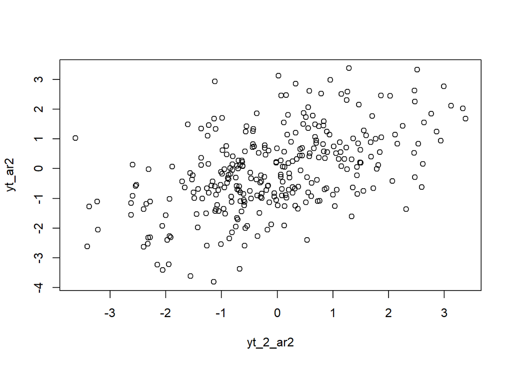

```r
plot(y=yt_ar2,x=yt_2_ar2)
```

Berdasarkan scatterplot tersebut, terlihat bahwa terdapat hubungan positif antara $Y_t$ dengan $Y_{t-2}$. Hal ini sesuai dengan teori yang ada

```r
cor(yt_ar2,yt_2_ar2)
```

```
## [1] 0.5176251
```

#### Korelasi antara $Y_t$ dengan $Y_{t-3}$

```r
#Yt
yt_ar2 <- ar2[-c(1,2,3)]
yt_ar2
```

```
##   [1] -1.010957436 -2.595601924 -2.539895627  0.135099830 -0.587612557
##   [6]  0.062881427 -1.121662286 -0.196746715 -0.598038053 -0.725736220
##  [11] -1.053294182 -1.663003076 -1.422635739 -0.629944187 -0.686127624
##  [16]  0.217581499 -0.722747495 -0.160691255  0.101012122 -0.566744612
##  [21]  0.073656551  1.243158192  2.470800309  0.711268215 -0.290944221
##  [26] -0.374751126 -0.221705995 -0.364932743  0.703316468  1.867772162
##  [31]  0.955796053  2.469579753  2.993735253  2.635760648  2.769842617
##  [36]  1.551591479  1.846947075 -0.744491075  0.559766910 -0.306104105
##  [41] -0.806377951 -0.469489115  0.150443138 -0.332375194 -0.888023314
##  [46]  0.535932097 -0.318263458 -2.401184208 -1.487630879 -1.368579826
##  [51] -0.989775631  1.356114931  1.709392163 -0.633670165  1.770677990
##  [56]  0.274219021  1.000219974 -0.808515059 -0.871916643 -2.151063102
##  [61] -0.350407053 -3.234663999 -2.279539723 -1.114053857 -2.319244900
##  [66] -1.430136190 -2.322809507 -1.975066728 -2.531479937 -2.399113628
##  [71] -0.538788396 -2.628538819 -1.931605552 -1.159526399 -1.014676079
```

[output cut: 45 more lines]

```r
#Yt-2
yt_3_ar2 <- ar2[-c(298,299,300)]
yt_3_ar2
```

```
##   [1]  0.133295622 -0.471960465 -1.261288985 -1.010957436 -2.595601924
##   [6] -2.539895627  0.135099830 -0.587612557  0.062881427 -1.121662286
##  [11] -0.196746715 -0.598038053 -0.725736220 -1.053294182 -1.663003076
##  [16] -1.422635739 -0.629944187 -0.686127624  0.217581499 -0.722747495
##  [21] -0.160691255  0.101012122 -0.566744612  0.073656551  1.243158192
##  [26]  2.470800309  0.711268215 -0.290944221 -0.374751126 -0.221705995
##  [31] -0.364932743  0.703316468  1.867772162  0.955796053  2.469579753
##  [36]  2.993735253  2.635760648  2.769842617  1.551591479  1.846947075
##  [41] -0.744491075  0.559766910 -0.306104105 -0.806377951 -0.469489115
##  [46]  0.150443138 -0.332375194 -0.888023314  0.535932097 -0.318263458
##  [51] -2.401184208 -1.487630879 -1.368579826 -0.989775631  1.356114931
##  [56]  1.709392163 -0.633670165  1.770677990  0.274219021  1.000219974
##  [61] -0.808515059 -0.871916643 -2.151063102 -0.350407053 -3.234663999
##  [66] -2.279539723 -1.114053857 -2.319244900 -1.430136190 -2.322809507
##  [71] -1.975066728 -2.531479937 -2.399113628 -0.538788396 -2.628538819
```

[output cut: 45 more lines]

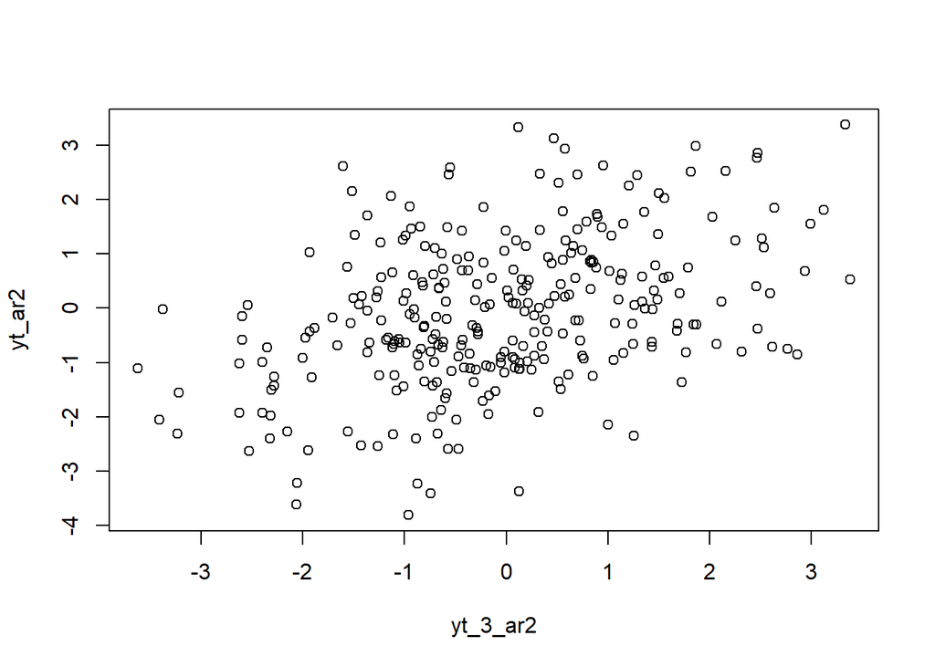

```r
plot(y=yt_ar2,x=yt_3_ar2)
```

Berdasarkan scatterplot tersebut, terlihat bahwa terdapat hubungan positif antara $Y_t$ dengan $Y_{t-3}$. Hal ini sesuai dengan teori yang ada

```r
cor(yt_ar2,yt_3_ar2)
```

```
## [1] 0.3988464
```

## Fungsi pembangkitan ARMA(2,2)

Pertama, lihat kembali bentuk umum data berpola ARMA.

$$y_{t} = c + \sum_{i=1}^p \phi_{i}y_{t-i} + \sum_{j=1}^q e_{t-j}+ e_{t}$$

Komponen $c$ dan $e_{t}$ cukup mudah untuk dibuat dan dicari. Bagaimana untuk komponen AR dan MA? Bayangkan ada koefisien dan data sebagai berikut:

$$\begin{aligned}
\begin{bmatrix}
\phi_1 \ \phi_2 \
\end{bmatrix}&=
\begin{bmatrix}
0.5 \ 0.2 \
\end{bmatrix}
\\
\begin{bmatrix}
\theta_1 \ \theta_2
\end{bmatrix}&=
\begin{bmatrix}
0.4 \ 0.6
\end{bmatrix}
\end{aligned}$$

```r
set.seed(1010)
n = length(wn)
phi1 = 0.5
phi2 = 0.2
theta1 = 0.4
theta2 = 0.6

y.arma=c(1:n)
for (i in 3:n){y.arma[i] = phi1*y.arma[i-1] + theta1*wn[i-1]+wn[i] + phi2*y.arma[i-2] + theta2*wn[i-2]+wn[i]}
y.arma
```

```
##   [1]   1.00000000   2.00000000   2.41231075   4.54427419   4.33465664
##   [6]   5.19037258   2.15242020   3.26989465   3.82462100   5.57795659
##  [11]   2.19511233   1.98683033   0.10613286  -0.67815317  -2.14240873
##  [16]  -2.35141338  -2.57186292  -0.55762014  -1.34478877  -1.27433237
##  [21]   0.48657259  -0.33604326  -1.99087294  -3.67145347  -2.66274135
##  [26]  -6.43996618  -4.88525444  -4.88534988  -4.26912160  -3.84696126
##  [31]  -4.12271428  -5.27075123  -4.32469469  -3.56869138   1.69887371
##  [36]   3.23777896   2.61368894   5.86838437   3.97982524   4.01541348
##  [41]   3.22596621   4.63090877   1.59219035   2.70188388  -1.35886402
##  [46]  -4.61587982  -6.13782973  -4.86304446  -0.33208528   0.19360930
##  [51]   0.77990989   1.86391084   2.55069966   0.65307556   0.16323628
##  [56]   0.05055657  -0.52198627   1.34884338   1.47089137   1.54015095
##  [61]  -0.75995651  -3.77232948  -4.45840776  -6.71324988  -7.00260695
##  [66]  -3.98347770  -4.58375966  -1.30981656  -1.57846827  -0.76332779
##  [71]  -2.13512662  -3.10335972  -6.71841285  -3.45888967  -1.35433552
```

[output cut: 45 more lines]

Pembangkitan ARMA(p,q) juga dapat dilakukan dengan fungsi `arima.sim` sebagai berikut.

```r
arma22 <- arima.sim(list(order=c(2,0,2), ar = c(0.5, 0.2), ma = c(0.4, 0.6)), n=300)
arma22
```

```
## Time Series:
## Start = 1
## End = 300
## Frequency = 1
##   [1] -1.3696174977 -1.7982846779 -3.7564803134 -4.1844989443 -2.4380580230
##   [6] -2.0573868423 -0.0910098080 -1.4490056726 -0.6076282073 -1.3496925124
##  [11] -1.0829677579 -1.7023873257 -2.5197440501 -2.7197994281 -2.1967896169
##  [16] -1.7916785770 -0.4348298378 -1.0473867239 -0.3192377354 -0.3969101190
##  [21] -0.6227524142 -0.0924324177  0.9325752668  3.0122584478  2.4454839633
##  [26]  1.4760437919 -0.0643674725 -0.5461726632 -0.6784655769  0.4243199563
##  [31]  1.9301392423  2.1248949046  3.9725615519  4.5550448477  5.3150026476
##  [36]  5.6203880642  4.2409849415  4.1294892573  0.9252426580  1.3701387371
##  [41] -0.5288919768 -0.5929594395 -0.9757027529 -0.5211792743 -0.5538914045
##  [46] -0.9307075065 -0.0187023435 -0.6367046061 -2.2069303322 -2.6390626356
##  [51] -3.4043427015 -2.4297860877  0.1390567838  1.6579727568  0.8637556594
```

[output cut: 49 more lines]

### Plot Time Series

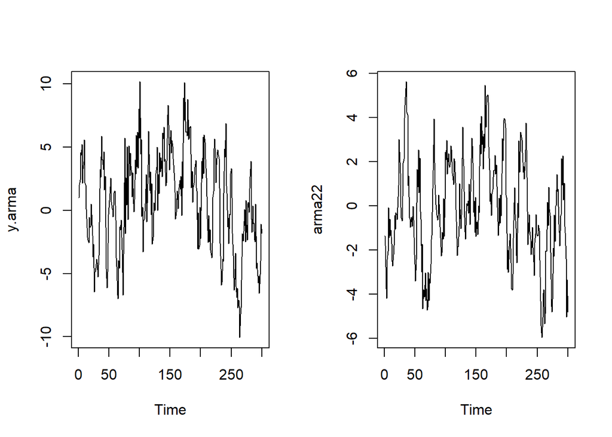

```r
par(mfrow = c(1, 2))
ts.plot(y.arma)
ts.plot(arma22)
```

```r
par(mfrow = c(1, 1))
```

Berdasarkan plot time series tersebut, terlihat bahwa model ARMA(2,2) cenderung stasioner dalam rataan

### Plot ACF

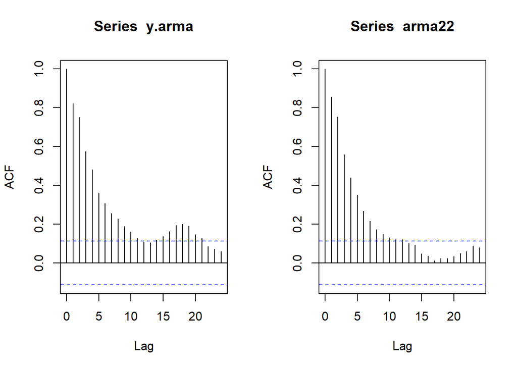

```r
par(mfrow = c(1, 2))
acf(y.arma)
acf(arma22)
```

```r
par(mfrow = c(1, 1))
```

Berdasarkan plot ACF tersebut, terlihat bahwa model ARMA(2,2) hasil simulasi memiliki plot ACF yang *tails off*, sesuai dengan teori yang ada

### Plot PACF

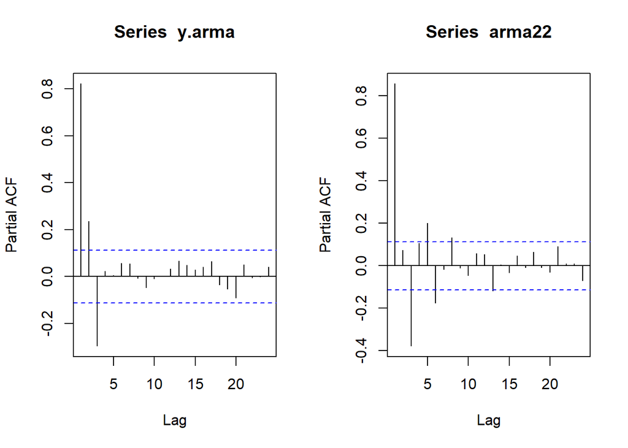

```r
par(mfrow = c(1, 2))
pacf(y.arma)
pacf(arma22)
```

```r
par(mfrow = c(1, 1))
```

Berdasarkan plot PACF tersebut, terlihat bahwa model ARMA(2,2) hasil simulasi memiliki plot PACF yang *tails off*, sesuai dengan teori

### Plot EACF

```r
TSA::eacf(y.arma)
```

```
## AR/MA
##   0 1 2 3 4 5 6 7 8 9 10 11 12 13
## 0 x x x x x x x x x x x  o  o  x
## 1 x x x x x o o o o o o  o  o  o
## 2 x x x o x o o o o o o  o  o  o
## 3 o o x o o o o o o o o  o  o  o
## 4 x o o o o o o o o o o  o  o  o
## 5 o x o o o o o o o o o  o  o  o
## 6 x x o o x o o o o o o  o  o  o
## 7 o x x o o o o o o o o  o  o  o
```

```r
TSA::eacf(arma22)
```

```
## AR/MA
##   0 1 2 3 4 5 6 7 8 9 10 11 12 13
## 0 x x x x x x x x x x x  x  o  o
## 1 o x o o o o o o o o o  o  o  o
## 2 x x x o o o o o o o o  o  o  o
## 3 x x x o o o o o o o o  o  o  o
## 4 x x o o o o o o o o o  o  o  o
## 5 x x x o x o o o o o o  o  o  o
## 6 o x o o x o o o o o o  o  o  o
## 7 x x x o x x o o o o o  o  o  o
```

### Scatterplot Antar Lag

#### Korelasi antara $Y_t$ dengan $Y_{t-1}$

```r
#Yt
yt_arma22 <- arma22[-1]
yt_arma22
```

```
##   [1] -1.7982846779 -3.7564803134 -4.1844989443 -2.4380580230 -2.0573868423
##   [6] -0.0910098080 -1.4490056726 -0.6076282073 -1.3496925124 -1.0829677579
##  [11] -1.7023873257 -2.5197440501 -2.7197994281 -2.1967896169 -1.7916785770
##  [16] -0.4348298378 -1.0473867239 -0.3192377354 -0.3969101190 -0.6227524142
##  [21] -0.0924324177  0.9325752668  3.0122584478  2.4454839633  1.4760437919
##  [26] -0.0643674725 -0.5461726632 -0.6784655769  0.4243199563  1.9301392423
##  [31]  2.1248949046  3.9725615519  4.5550448477  5.3150026476  5.6203880642
##  [36]  4.2409849415  4.1294892573  0.9252426580  1.3701387371 -0.5288919768
##  [41] -0.5929594395 -0.9757027529 -0.5211792743 -0.5538914045 -0.9307075065
##  [46] -0.0187023435 -0.6367046061 -2.2069303322 -2.6390626356 -3.4043427015
##  [51] -2.4297860877  0.1390567838  1.6579727568  0.8637556594  2.5428452215
##  [56]  0.6022881183  2.1723143763 -0.2438956571 -0.5951906827 -2.9849387954
##  [61] -1.7339822802 -4.6654646818 -3.7836495546 -3.9666681459 -4.1325902763
##  [66] -3.0262664639 -4.2864109226 -3.7622722444 -4.7151923322 -4.5967456399
##  [71] -3.0173218097 -4.2835223541 -3.3062941169 -3.5092919106 -2.6374499698
```

[output cut: 45 more lines]

```r
#Yt-1
yt_1_arma22 <- arma22[-300]
yt_1_arma22
```

```
##   [1] -1.3696174977 -1.7982846779 -3.7564803134 -4.1844989443 -2.4380580230
##   [6] -2.0573868423 -0.0910098080 -1.4490056726 -0.6076282073 -1.3496925124
##  [11] -1.0829677579 -1.7023873257 -2.5197440501 -2.7197994281 -2.1967896169
##  [16] -1.7916785770 -0.4348298378 -1.0473867239 -0.3192377354 -0.3969101190
##  [21] -0.6227524142 -0.0924324177  0.9325752668  3.0122584478  2.4454839633
##  [26]  1.4760437919 -0.0643674725 -0.5461726632 -0.6784655769  0.4243199563
##  [31]  1.9301392423  2.1248949046  3.9725615519  4.5550448477  5.3150026476
##  [36]  5.6203880642  4.2409849415  4.1294892573  0.9252426580  1.3701387371
##  [41] -0.5288919768 -0.5929594395 -0.9757027529 -0.5211792743 -0.5538914045
##  [46] -0.9307075065 -0.0187023435 -0.6367046061 -2.2069303322 -2.6390626356
##  [51] -3.4043427015 -2.4297860877  0.1390567838  1.6579727568  0.8637556594
##  [56]  2.5428452215  0.6022881183  2.1723143763 -0.2438956571 -0.5951906827
##  [61] -2.9849387954 -1.7339822802 -4.6654646818 -3.7836495546 -3.9666681459
##  [66] -4.1325902763 -3.0262664639 -4.2864109226 -3.7622722444 -4.7151923322
##  [71] -4.5967456399 -3.0173218097 -4.2835223541 -3.3062941169 -3.5092919106
```

[output cut: 45 more lines]

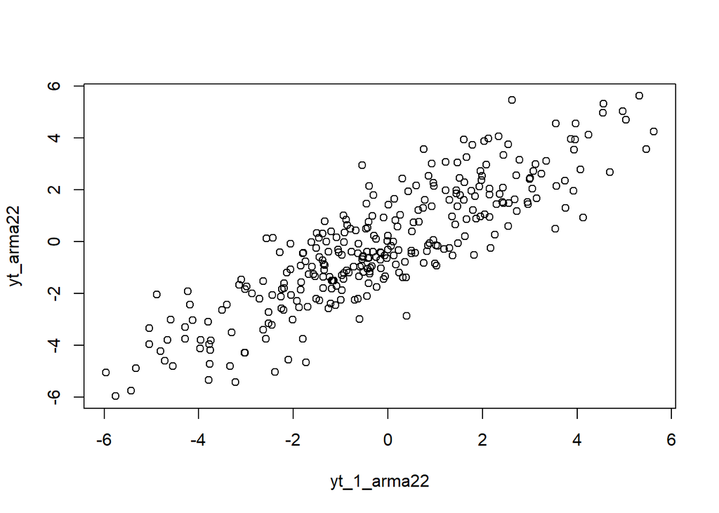

```r
plot(y=yt_arma22,x=yt_1_arma22)
```

Berdasarkan scatterplot tersebut, terlihat bahwa terdapat hubungan positif antara $Y_t$ dengan $Y_{t-1}$. Hal ini sesuai dengan teori yang ada

```r
cor(yt_arma22,yt_1_arma22)
```

```
## [1] 0.8624714
```

$$\rho_k = \frac{(1-\theta
\phi)(\phi-\theta)}{1-2\theta\phi+\theta^2}\phi^{k-1} \:untuk
\:k\ge1$$